# FinalProject_Individual

Acousticness is the most intriguing of the three variables. Songs that use electronic amplification fall on the extremes, either having low danceability and valence or high danceability and valence, while songs without electronic amplification tend to fall in the middle, hacing middling danceability and valence. This relationship can be explained by four of the genres. Low acoustic rap and pop songs tend to be more positive and danceable, while low acoustic metal tends to have low daceability and valence. This is likely attributable to the nature of each genre, as metal is not something that is often danced to or uplifting, while rap and pop tend to have the opposite characteristics. Since electronic amplification is used widely in all three, this is likely what is causing this relationship to appear. Additionally, jazz has middling values all, filling in the gap between metal and rap/pop. Acousticness tends to lack an obvious relationship with danceability and valence in the other genres. So how much of a relationship this is is debateable since a few genres are creating the appearance of a relationship for all genres.

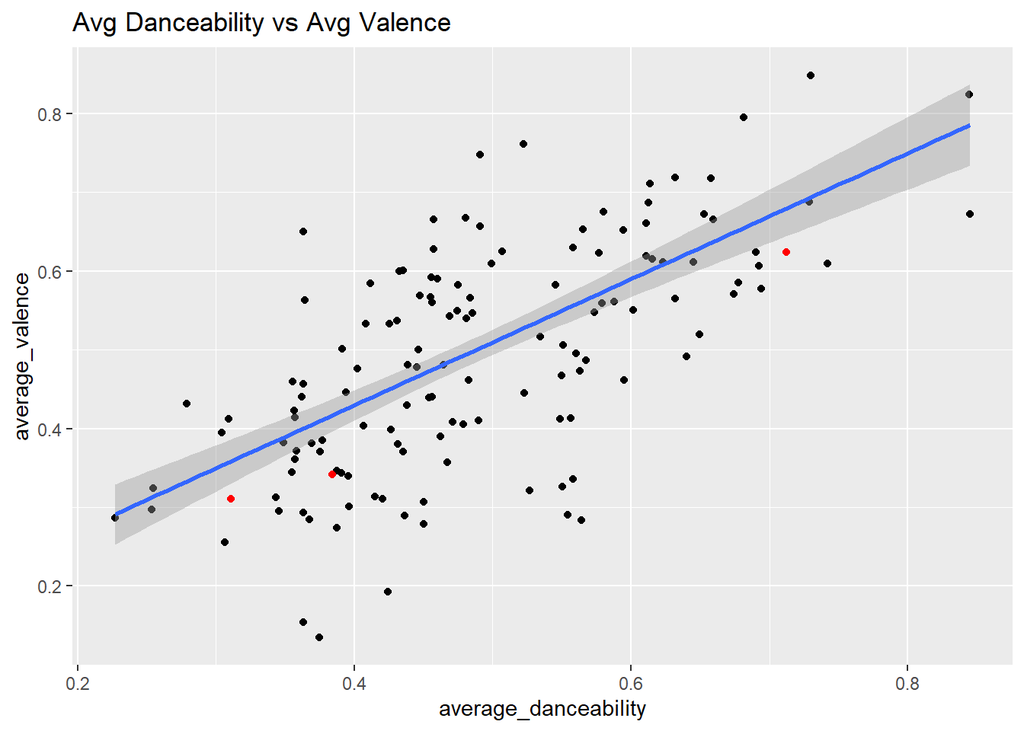

```r
byGenre %>% ggplot(aes(x=average_danceability, y=average_valence)) +
  geom_point() +
  geom_point(data = topAlbums, color = "red") +
  geom_smooth(method = "lm") +
  labs(title = "Avg Danceability vs Avg Valence")
```

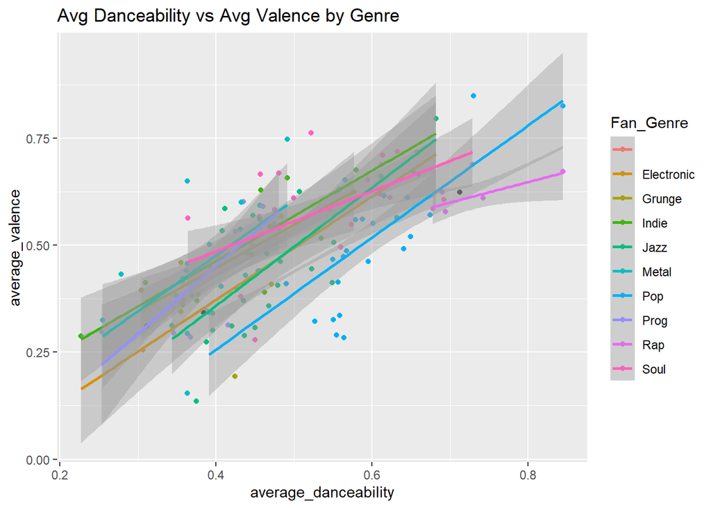

```r
byGenre %>% ggplot(aes(x=average_danceability, y=average_valence, color=Fan_Genre)) +
  geom_point() +
  geom_point(data = topAlbums, color = "black") +
  geom_smooth(method = "lm") +
  labs(title = "Avg Danceability vs Avg Valence by Genre")
```

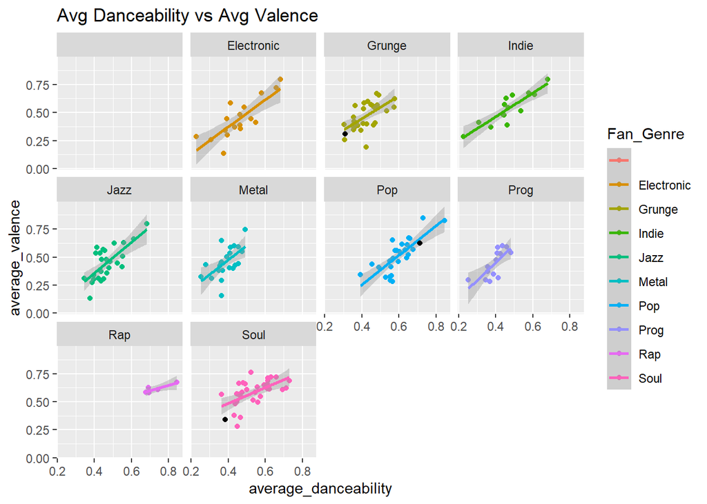

```r
byGenre %>% ggplot(aes(x=average_danceability, y=average_valence, color=Fan_Genre)) +
  geom_point() +
  geom_smooth(method = "lm") +
  geom_point(data = topAlbums, color = "black") +
  labs(title = "Avg Danceability vs Avg Valence") +
  facet_wrap(~Fan_Genre)
```

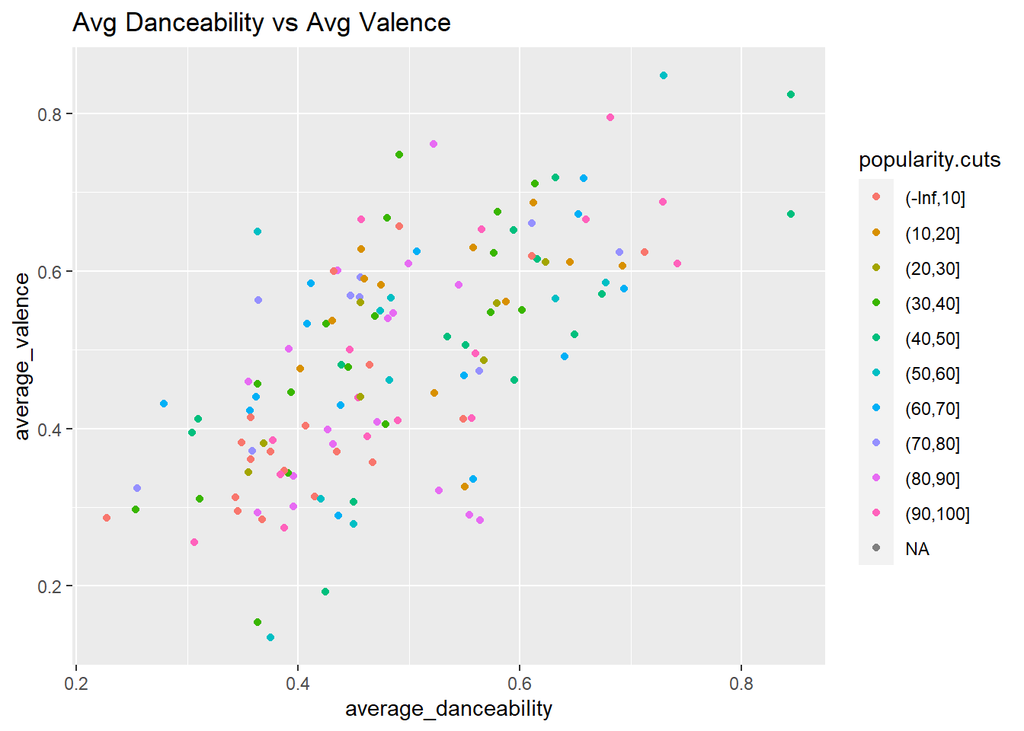

```r
byGenre <- byGenre %>%
  mutate(popularity.cuts = cut(Popularity, c(-Inf, 10, 20, 30, 40, 50, 60, 70, 80, 90, 100))) %>%
  mutate(liveliness.cuts = cut(average_liveness, c(-Inf, 0.1, 0.2, 0.3, 0.4, 0.5, 0.6, 0.7, 0.8, 0.9, 1))) %>%
  mutate(loudness.cuts = cut(average_loudness, c(Inf, -3, -6, -9, -12, -15, -18, -21, -24, -27, -Inf))) %>%
  mutate(tempo.cuts = cut(average_tempo, c(0, 85, 95, 105, 115, 125, 135, 145, 155, 165, 175, Inf))) %>%
  mutate(energy.cuts = cut(average_energy, c(-Inf, 0.1, 0.2, 0.3, 0.4, 0.5, 0.6, 0.7, 0.8, 0.9, 1))) %>%
  mutate(instrumental.cuts = cut(average_instrumentalness, c(-Inf, 0.1, 0.2, 0.3, 0.4, 0.5, 0.6, 0.7, 0.8, 0.9, 1))) %>%
    mutate(acoustic.cuts = cut(average_acousticness, c(-Inf, 0.1, 0.2, 0.3, 0.4, 0.5, 0.6, 0.7, 0.8, 0.9, 1)))

byGenre %>% ggplot(aes(x=average_danceability, y=average_valence, color=popularity.cuts)) +
  geom_point() +
  labs(title = "Avg Danceability vs Avg Valence")
```

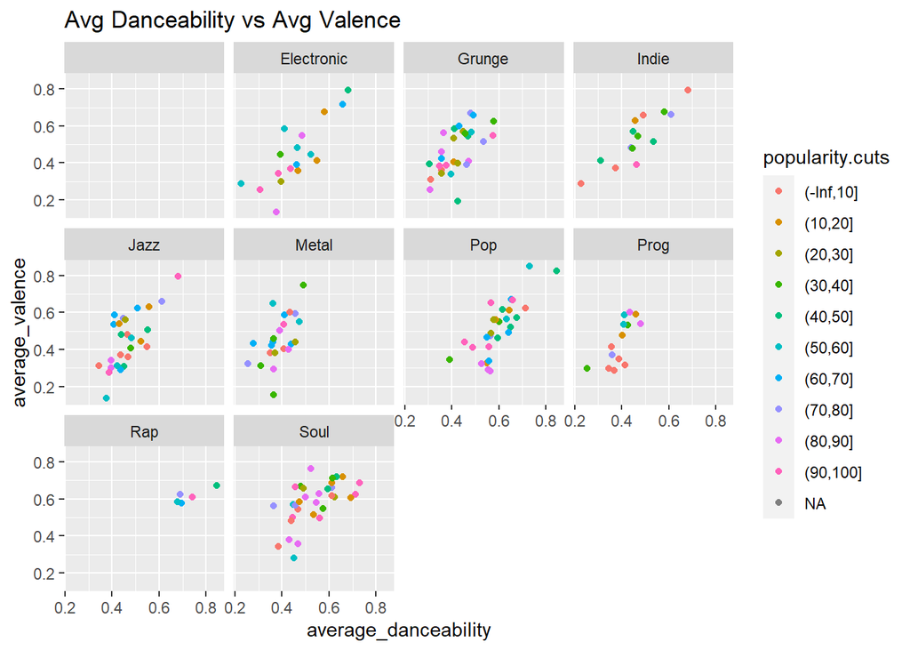

```r
byGenre %>% ggplot(aes(x=average_danceability, y=average_valence, color=popularity.cuts)) +
  geom_point() +
  labs(title = "Avg Danceability vs Avg Valence") +
  facet_wrap(~Fan_Genre)
```

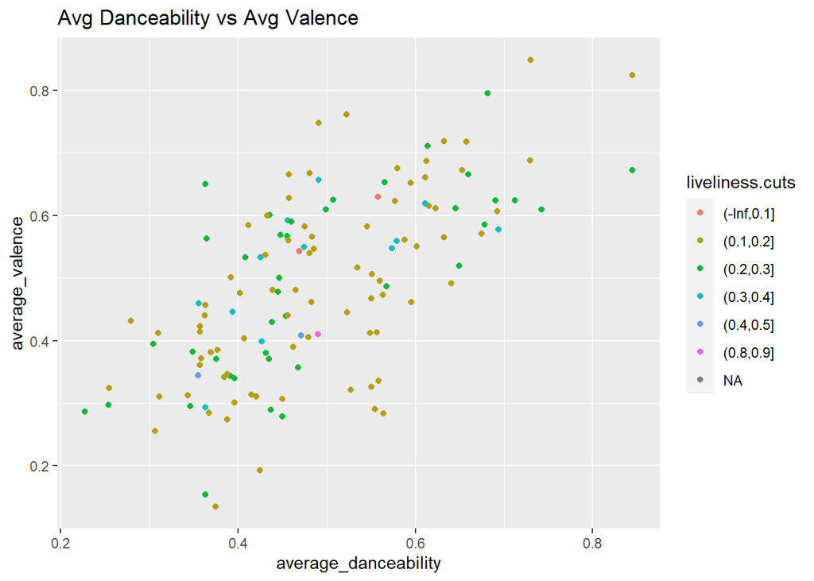

```r
byGenre %>% ggplot(aes(x=average_danceability, y=average_valence, color=liveliness.cuts)) +
  geom_point() +
  labs(title = "Avg Danceability vs Avg Valence")
```

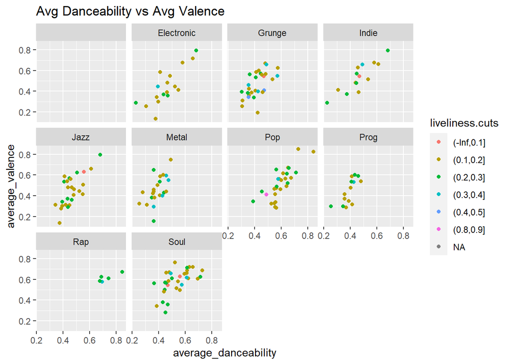

```r
byGenre %>% ggplot(aes(x=average_danceability, y=average_valence, color=liveliness.cuts)) +
  geom_point() +
  labs(title = "Avg Danceability vs Avg Valence") +
  facet_wrap(~Fan_Genre)
```

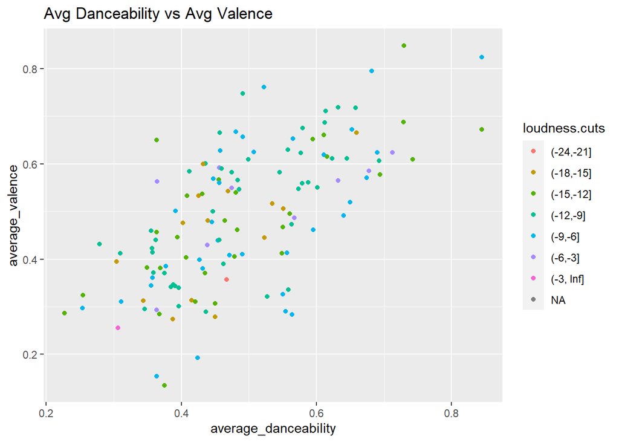

```r
byGenre %>% ggplot(aes(x=average_danceability, y=average_valence, color=loudness.cuts)) +
  geom_point() +
  labs(title = "Avg Danceability vs Avg Valence")
```

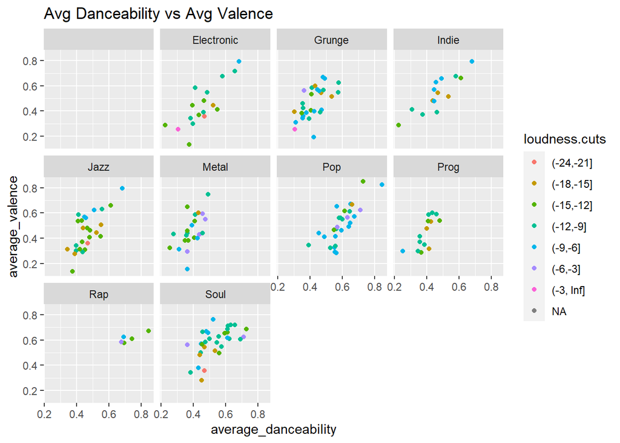

```r
byGenre %>% ggplot(aes(x=average_danceability, y=average_valence, color=loudness.cuts)) +
  geom_point() +
  labs(title = "Avg Danceability vs Avg Valence") +
  facet_wrap(~Fan_Genre)
```

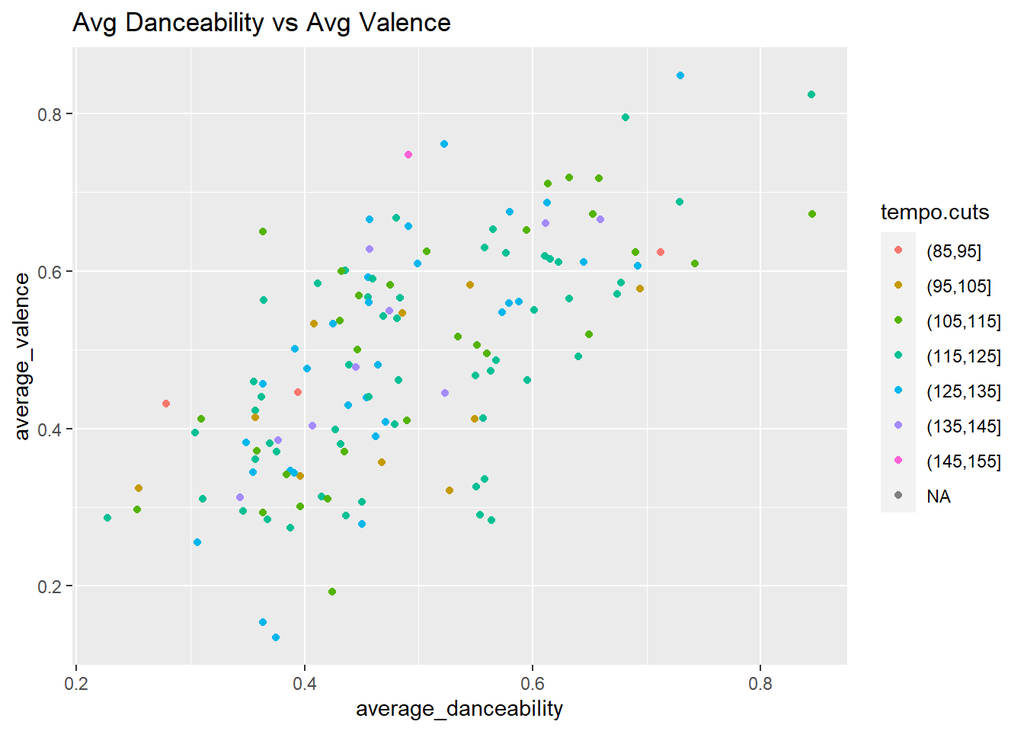

```r
byGenre %>% ggplot(aes(x=average_danceability, y=average_valence, color=tempo.cuts)) +
  geom_point() +
  labs(title = "Avg Danceability vs Avg Valence")
```

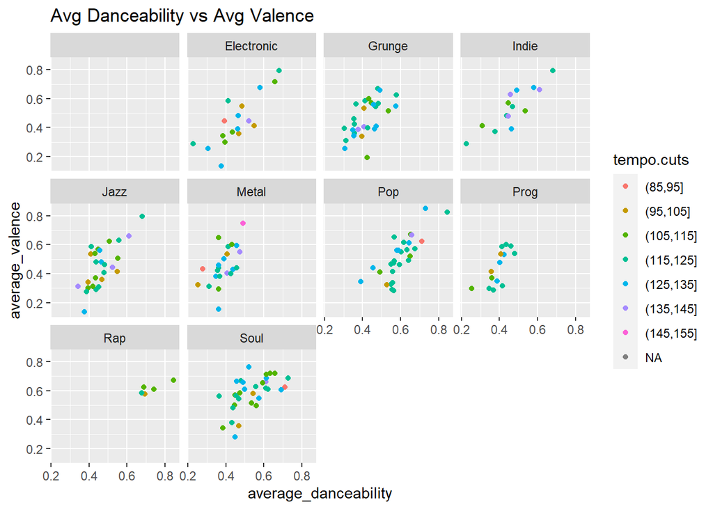

```r
byGenre %>% ggplot(aes(x=average_danceability, y=average_valence, color=tempo.cuts)) +
  geom_point() +
  labs(title = "Avg Danceability vs Avg Valence") +
  facet_wrap(~Fan_Genre)
```

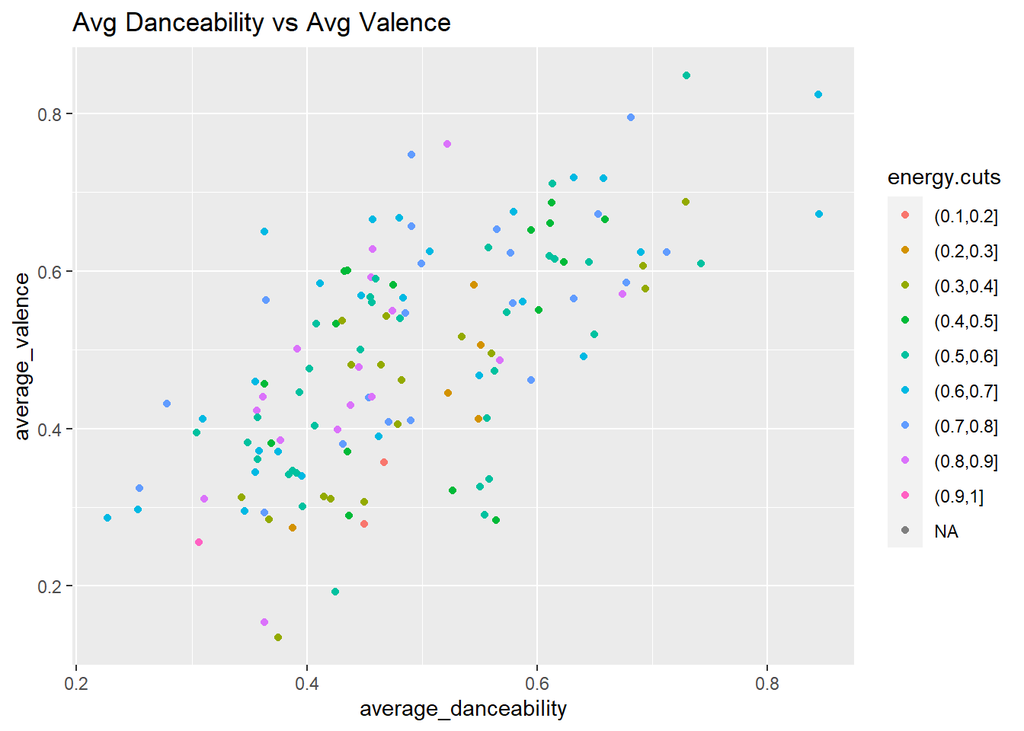

```r
byGenre %>% ggplot(aes(x=average_danceability, y=average_valence, color=energy.cuts)) +
  geom_point() +
  labs(title = "Avg Danceability vs Avg Valence")
```

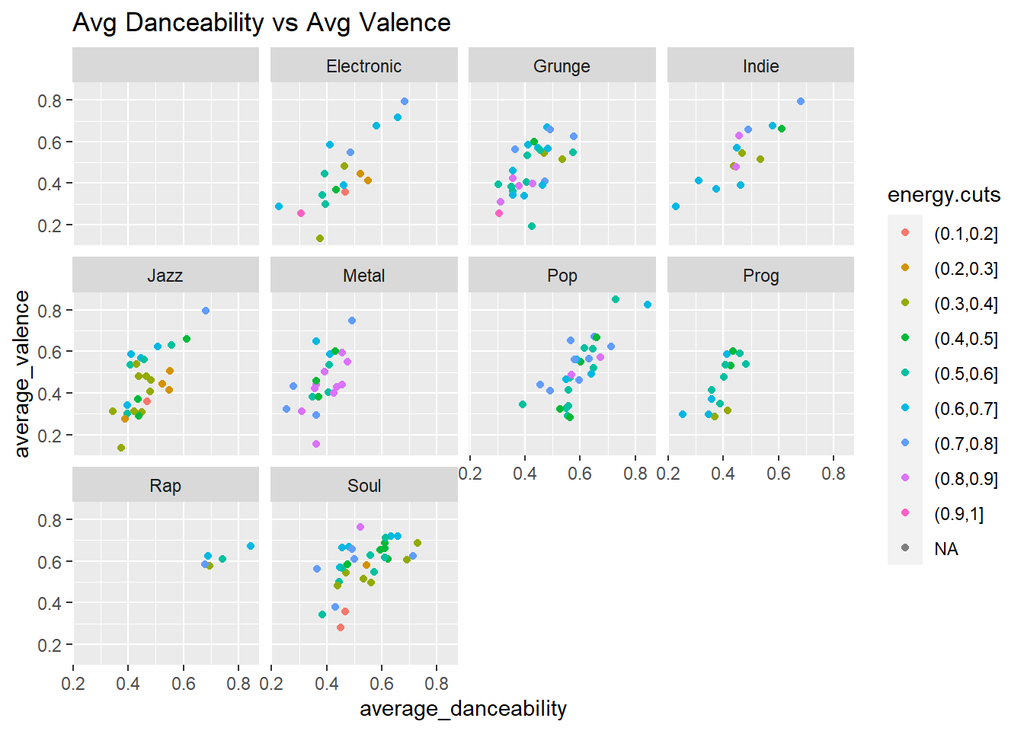

```r
byGenre %>% ggplot(aes(x=average_danceability, y=average_valence, color=energy.cuts)) +
  geom_point() +
  labs(title = "Avg Danceability vs Avg Valence") +
  facet_wrap(~Fan_Genre)
```

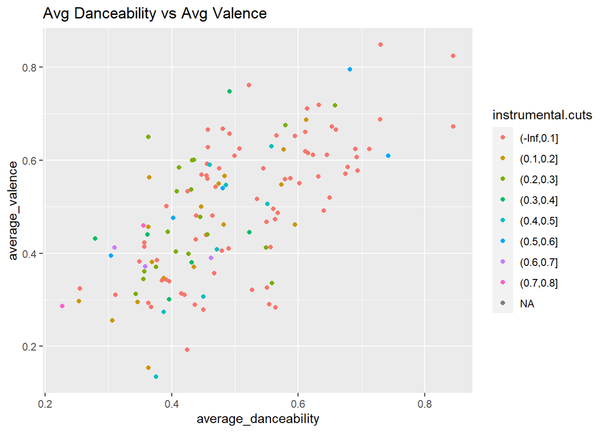

```r
byGenre %>% ggplot(aes(x=average_danceability, y=average_valence, color=instrumental.cuts)) +
  geom_point() +
  labs(title = "Avg Danceability vs Avg Valence")
```

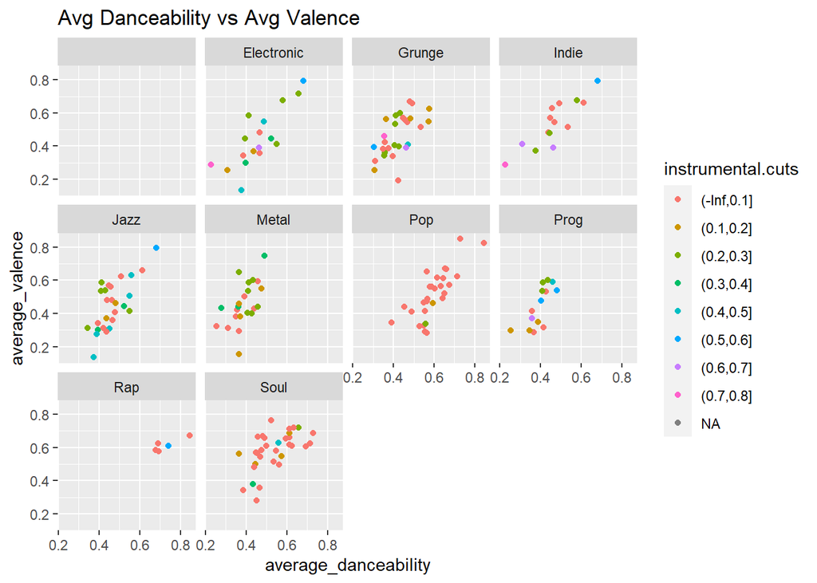

```r
byGenre %>% ggplot(aes(x=average_danceability, y=average_valence, color=instrumental.cuts)) +
  geom_point() +
  labs(title = "Avg Danceability vs Avg Valence") +
  facet_wrap(~Fan_Genre)
```

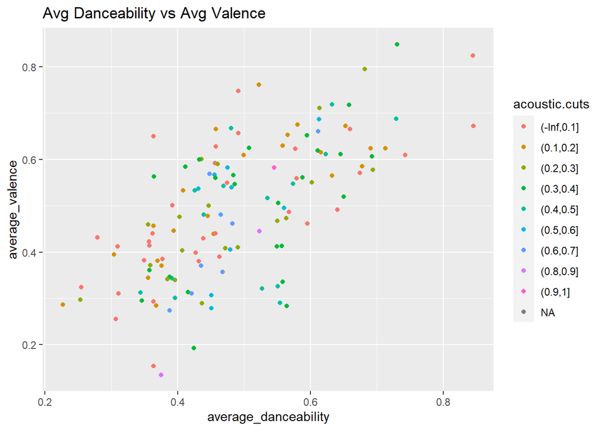

```r
byGenre %>% ggplot(aes(x=average_danceability, y=average_valence, color=acoustic.cuts)) +
  geom_point() +
  labs(title = "Avg Danceability vs Avg Valence")
```

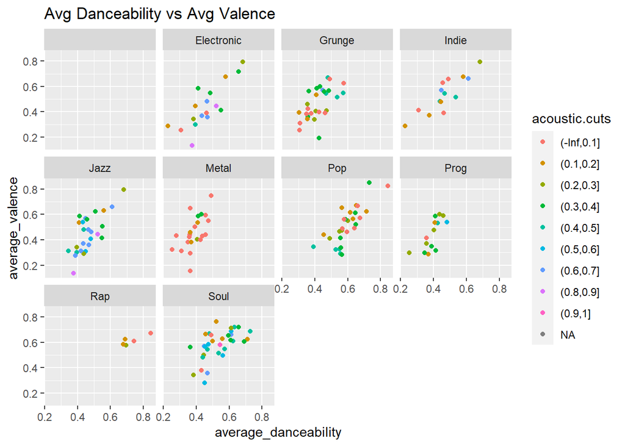

```r
byGenre %>% ggplot(aes(x=average_danceability, y=average_valence, color=acoustic.cuts)) +
  geom_point() +
  labs(title = "Avg Danceability vs Avg Valence") +
  facet_wrap(~Fan_Genre)
```

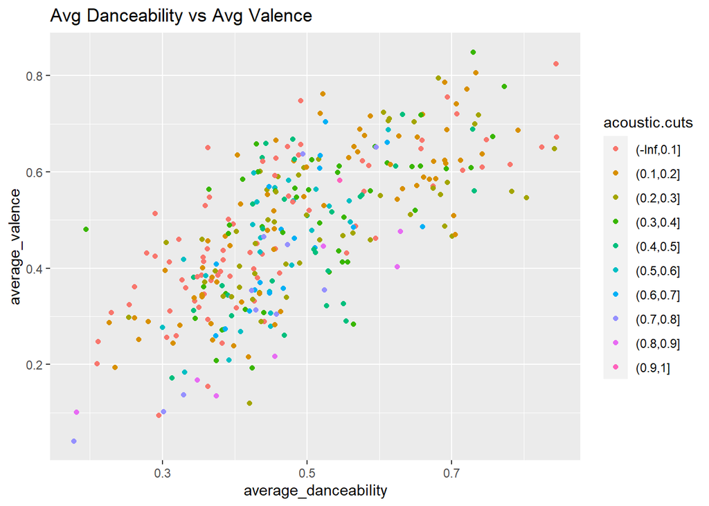

```r
data <- read.csv("Album_Label_Year.csv")
byAlbum <- data %>% group_by(Album_label) %>% filter(!(is.na(average_valence) | is.na(average_danceability))) %>%
  mutate(acoustic.cuts = cut(average_acousticness, c(-Inf, 0.1, 0.2, 0.3, 0.4, 0.5, 0.6, 0.7, 0.8, 0.9, 1))) %>%
  mutate(instrumental.cuts = cut(average_instrumentalness, c(-Inf, 0.5, 1)))

labels <- data %>% group_by(Album_label) %>% count(Album_label) %>% filter(n >= 7) %>% select(Album_label)

byAlbum <- byAlbum %>% filter(Album_label %in% labels$Album_label)

byAlbum %>% ggplot(aes(x=average_danceability, y=average_valence, color=acoustic.cuts)) +
  geom_point() +
  labs(title = "Avg Danceability vs Avg Valence")
```

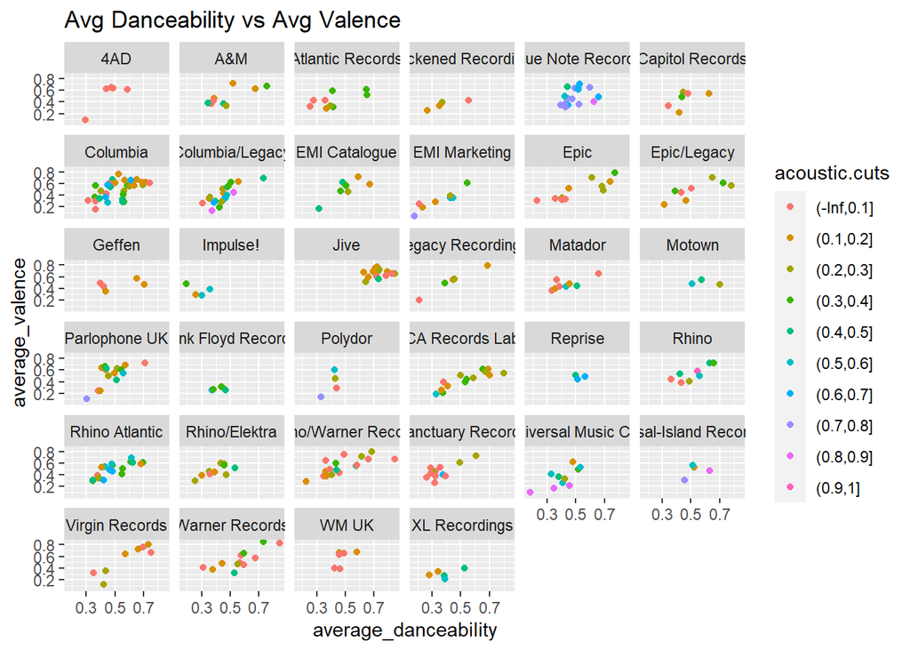

```r
byAlbum %>% ggplot(aes(x=average_danceability, y=average_valence, color = acoustic.cuts)) +
  geom_point() +
  labs(title = "Avg Danceability vs Avg Valence") +
  facet_wrap(~Album_label)
```